# Uncertainty and intervals

Ben Whalley

September 2020

# Beyond intervals

One of the nice things about modern Bayesian methods is that we don’t have to pick just a single number to represent our estimate, or a single interval to represent our uncertainty.

As mentioned in the main workshop notes, to fit the model, the computer runs a simulation thousands of time. On each run, it can make a prediction.

Because of the way the method works, predictions from the simulation are made *in proportion* to their probability.

This means that:

1. If we plot the simulation results, we can see what is the most likely *distribution* of outcomes.
2. By counting different outcomes within the simulation, and doing simple arithmetic, we can calculate the *probability* of different outcomes occuring.

## Before you start

Make sure you have the data loaded and have run the Rstanarm version of the model in your current R session:

```r
kidiq <- read_csv("http://bit.ly/arm-kids-iq")
```

```r
library(rstanarm) # load this first to make stan_glm available
iqmodel.bayes <- stan_glm(kid_score ~ mom_iq + mom_hs, data=kidiq)
```

## Visualising the posterior distribution

Many experts in Bayesian methods recommend avoiding single-number summaries rather than trying to summarise the simulation results as a single value or range (e.g. see [Gabry et al](https://arxiv.org/abs/1709.01449), although this covers many more advanced topics too).

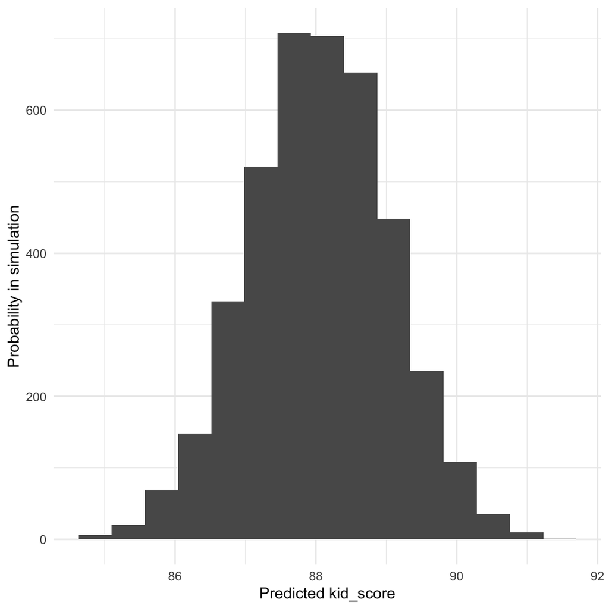

```r
new.mother = tibble(mom_iq=100, mom_hs="Completed")
fitted_draws(iqmodel.bayes, newdata=new.mother) %>%
  ggplot(aes(.value)) +
  geom_histogram(bins=15) +
  ylab("Probability in simulation") +
  xlab("Predicted kid_score")
```

Make new predictions (using `fitted_draws`) for the *average* `kid_score` for a mother with an IQ of 120 who completed school.

Visualise these predictions using `ggplot`. It should look something like this if you use a density plot (`geom_density`) instead of a histogram:

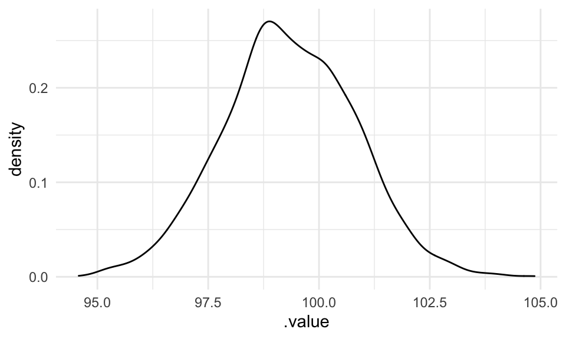

Now make predictions for new *individuals*, who have the same IQ and who completed school (i.e. use the `predicted_draws` function). Plot the predictions; they should look something like this:

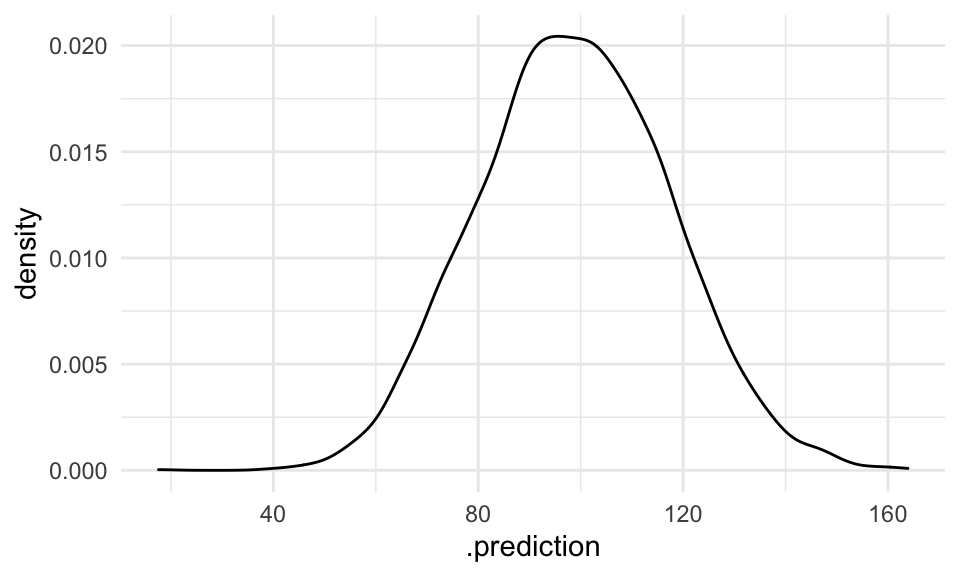

Are you more certain about the future *average* prediction, or the future *individual* prediction? How is this shown in your plots?

### Bayesian boxplots

Using `iqmodel.bayes`, predict *average* IQs for children of mothers with an IQ of 100, with OR without high school education.

Create a boxplot to compare the range of *average* outcomes for groups of mothers who had these characteristics. It should look something like this:

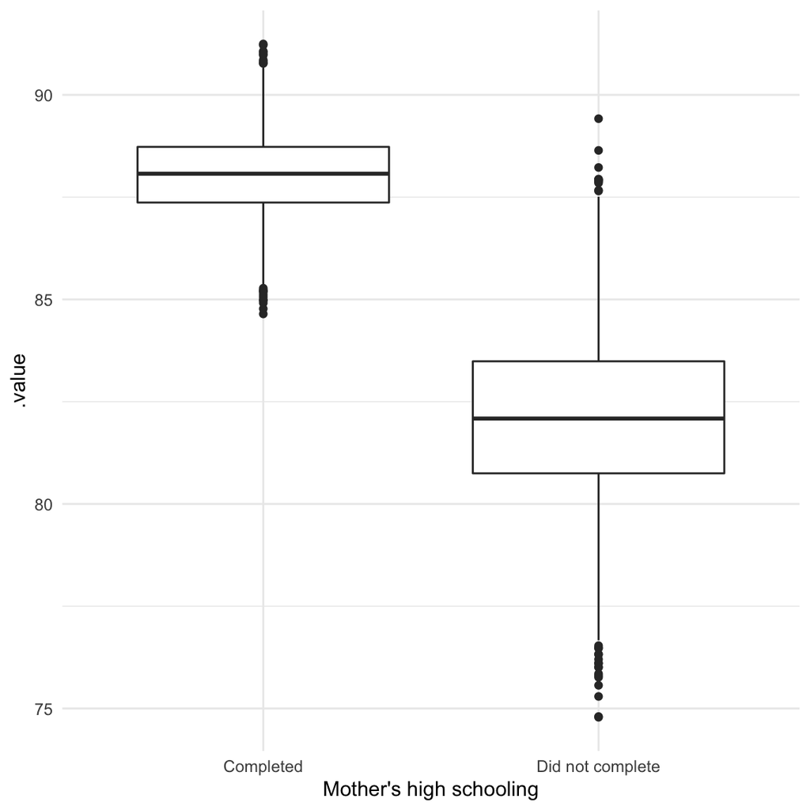

# Being a Bookie

Being a bookie is all about uncertainty for individual cases.

A bookmaker wants to know how often she will lose a particular bet, based on the information availale. If they can estimate this uncertainty they can make money! If they know how often they will win/lose a bet they can change the odds approprately.

Imagine a mother with an IQ of 100 wants to place a bet that their child will have an IQ > 110. If we know, from the data, that this will only happen around 5% of the time you could offer odds of around 19:1 and break even. To make money you would have to offer odds of less than that (say 18:1 or lower).

Applied psychologists, clinicians or policy makers might also want to do this. For example, they might want to base decisions on probability statements like:

To do this we can just run a model with rstanarm and *count* the number of times each outcome happened within our Bayesian simulation. For example:

```r
new.mother = tibble(mom_iq=100, mom_hs="Completed")

predicted_draws(iqmodel.bayes, newdata=new.mother) %>%
  summarise(mean(.prediction < 60))
> # A tibble: 1 x 4
> # Groups:   mom_iq, mom_hs [1]
>   mom_iq mom_hs     .row `mean(.prediction < 60)`
>    <dbl> <chr>     <int>                    <dbl>
> 1    100 Completed     1                   0.0532
```

**Explanation of the code:**

In the code above, `predicted_draws` makes predictions for `new.mother`… that is a new mother with an IQ = 100, and who completed high school. Rather than just one prediction, this makes many (thousands) of predictions for this new mother, one for each run of the model simulation.

It returns a predicted_draws, with a `.prediction` column, which is the predicted value for this individual in each simulation run.

We then use `summarise` to count how many times `pred < 60`. We do this within the `mean(...)` function; this converts the `TRUE` and `FALSE` values to `0` and `1` first, so the average of `c(TRUE, FALSE)` is 0.5.

In short, `mean(pred < 60)` gives us the *probability* that `.prediction` was less than 60 in all of the simulation runs.

What bet should we offer a mother with an IQ of 70 that her baby will have an IQ > 120?

If you don’t know how to convert probabilities into betting odds this calculator will do that for you: https://www.aceodds.com/bet-calculator/odds-converter.html Use the “implied probability” box.

Remember to use `predicted_draws` rather than `fitted_draws`

The answer depends a bit on whether you think the mother completed high school. We can calculate the probability for those who did/did not complete like this:

```r
new.mothers = tibble(mom_iq=70, mom_hs=c("Completed", "Did not complete"))

predicted_draws(iqmodel.bayes, newdata=new.mothers) %>%
  summarise(mean(.prediction > 120))
> # A tibble: 2 x 4
> # Groups:   mom_iq, mom_hs [2]
>   mom_iq mom_hs            .row `mean(.prediction > 120)`
>    <dbl> <chr>            <int>                     <dbl>
> 1     70 Completed            1                   0.00325
> 2     70 Did not complete     2                   0.00075
```

If we are a bookmaker we want to make a profit so we should offer less than this.

However we might also know that gamblers are subject to many biases in their reasoning and might not be able to [discriminate effectively when the odds are so large](https://en.wikipedia.org/wiki/Prospect_theory): we might get away with offering only 1000/1 because punters won’t notice the difference!